# INFSCI 2595 Final Project

Part 2A, Regression - Baseline Models

Zhenyu Li

2022-04-08

```r
library(tidyverse)
library(coefplot)
source("./scripts/utils.R")
theme_set(theme_linedraw())
```

```r
df <- readr::read_csv("./data/final_project_train.csv", col_names = TRUE)
sel_num <- df %>% select_if(is_double) %>% select(!rowid) %>% select(sort(names(.))) %>% colnames()
sel_num_in <- setdiff(sel_num,"response")
sel_cat <- df %>% select(!one_of(sel_num)) %>% select(!rowid) %>% colnames()
sel_cat_in <- setdiff(sel_cat, "outcome")
```

In this section, several baseline linear models are trained using `lm`.

- Models are compared based on AIC/BIC.
- Important features from the best models are discussed.

## Preprocessing

- For regression, the necessary preprocessing steps include:
  - Log-transform the continuous response
  - Standardize continuous inputs

```r
df_preproc <- df %>%
  mutate_if(is.character,as.factor) %>%
  select(-c(rowid,outcome)) %>%
  mutate(
    response = log(response),
    across(starts_with("x"), scale)
  )
```

## Model Fitting

**Create linear models to fit the data.**

### Predefined Models

**Fit 6 predefined linear models.**

1. Categorical variables only – linear additive
2. Continuous variables only – linear additive
3. All categorical and continuous variables – linear additive
4. Interact `region` with continuous inputs, do not include `customer`
5. Interact `customer` with continuous inputs, do not include `region`
6. All pairwise interactions of continuous inputs, do not include categorical inputs

Slice the data with certain inputs to facilitate model building.

```r
df_cat <- df_preproc %>% select(-all_of(sel_num_in))
df_num <- df_preproc %>% select(-all_of(sel_cat_in))
```

Fit models by providing formula.

```r
# fit the predefined models
mod_2A1 <- lm(response ~ ., df_cat)
mod_2A2 <- lm(response ~ ., df_num)
mod_2A3 <- lm(response ~ ., df_preproc)
mod_2A4 <- lm(response ~ (region) * (. -customer), df_preproc)
mod_2A5 <- lm(response ~ (customer) * (. -region), df_preproc)
mod_2A6 <- lm(response ~ (.)^2, df_num)
```

Get a quick comparison of models using information criterion.

```r
my_models <- mget(ls(pattern = "^mod_2A\\d+"))
calc_models_ic(my_models)
```

```
## # A tibble: 6 × 5
##   model     AIC   BIC adj.r.squared r.squared
##   <chr>   <dbl> <dbl>         <dbl>     <dbl>
## 1 mod_2A1  961. 1015.         0.170     0.182
## 2 mod_2A2  614.  772.         0.519     0.542
## 3 mod_2A3  406.  610.         0.651     0.673
## 4 mod_2A4  399.  865.         0.679     0.727
## 5 mod_2A5  510. 1870.         0.679     0.821
## 6 mod_2A6  451. 2994.         0.556     0.924
```

- `mod_2A3`: Linear additive relationship of all continuous and categorical inputs has the best BIC.
- `mod_2A4`: Adding interaction from `region` seems to improve AIC at the cost of BIC.

### Custom Basis Models

**Fit 4 custom basis models.**

- Input features that involve some non-linearity from EDA are
  - `xa, xb, xn` at index `03, 05, 08`
  - `xs` index `01, 04, 06`
  - `xw` index `01, 02, 03`

**1. Add non-linearity using 2 dof natural spline to these inputs, keep linear for the rest inputs. Linear additive only.**

```r
mod_2Ac1 <- lm(
  response ~ . +
    + splines::ns(xa_03,df=2) + splines::ns(xa_05,df=2) + splines::ns(xa_08,df=2)
    + splines::ns(xb_03,df=2) + splines::ns(xb_05,df=2) + splines::ns(xb_08,df=2)
    + splines::ns(xn_03,df=2) + splines::ns(xn_05,df=2) + splines::ns(xn_08,df=2)
    + splines::ns(xs_01,df=2) + splines::ns(xs_04,df=2) + splines::ns(xs_06,df=2)
    + splines::ns(xw_01,df=2) + splines::ns(xw_02,df=2) + splines::ns(xw_03,df=2)
    - xa_03 - xa_05 - xa_08
    - xb_03 - xb_05 - xb_08
    - xn_03 - xn_05 - xn_08
    - xs_01 - xs_04 - xs_06
    - xw_01 - xw_02 - xw_03,
  data=df_preproc)
calc_models_ic(list(mod_2Ac1))
```

```
## # A tibble: 1 × 5
##   model   AIC   BIC adj.r.squared r.squared
##   <chr> <dbl> <dbl>         <dbl>     <dbl>
## 1 1      367.  638.         0.677     0.705
```

**2. Remove categorical inputs, keep the rest as 2Ac1.**

```r
mod_2Ac2 <- lm(
    response ~ . - region - customer
    + splines::ns(xa_03,df=2) + splines::ns(xa_05,df=2) + splines::ns(xa_08,df=2)
    + splines::ns(xb_03,df=2) + splines::ns(xb_05,df=2) + splines::ns(xb_08,df=2)
    + splines::ns(xn_03,df=2) + splines::ns(xn_05,df=2) + splines::ns(xn_08,df=2)
    + splines::ns(xs_01,df=2) + splines::ns(xs_04,df=2) + splines::ns(xs_06,df=2)
    + splines::ns(xw_01,df=2) + splines::ns(xw_02,df=2) + splines::ns(xw_03,df=2)
    - xa_03 - xa_05 - xa_08
    - xb_03 - xb_05 - xb_08
    - xn_03 - xn_05 - xn_08
    - xs_01 - xs_04 - xs_06
    - xw_01 - xw_02 - xw_03,
  df_preproc)
calc_models_ic(list(mod_2Ac2))
```

```
## # A tibble: 1 × 5
##   model   AIC   BIC adj.r.squared r.squared
##   <chr> <dbl> <dbl>         <dbl>     <dbl>
## 1 1      592.  817.         0.544     0.576
```

**3. Interact `region` with the nonlinear features from 2Ac1, additive for the rest.**

```r
mod_2Ac3 <- lm(
  response ~ . - region + region :
    ( splines::ns(xa_03,df=2) + splines::ns(xa_05,df=2) + splines::ns(xa_08,df=2)
    + splines::ns(xb_03,df=2) + splines::ns(xb_05,df=2) + splines::ns(xb_08,df=2)
    + splines::ns(xn_03,df=2) + splines::ns(xn_05,df=2) + splines::ns(xn_08,df=2)
    + splines::ns(xs_01,df=2) + splines::ns(xs_04,df=2) + splines::ns(xs_06,df=2)
    + splines::ns(xw_01,df=2) + splines::ns(xw_02,df=2) + splines::ns(xw_03,df=2) )
    - xa_03 - xa_05 - xa_08
    - xb_03 - xb_05 - xb_08
    - xn_03 - xn_05 - xn_08
    - xs_01 - xs_04 - xs_06
    - xw_01 - xw_02 - xw_03,
  df_preproc)
calc_models_ic(list(mod_2Ac3))
```

```
## # A tibble: 1 × 5
##   model   AIC   BIC adj.r.squared r.squared
##   <chr> <dbl> <dbl>         <dbl>     <dbl>
## 1 1      320.  853.         0.720     0.768
```

**4. Use pair-wise interaction for all input variables.**

```r
mod_2Ac4 <- lm(response ~ (.)^2, df_preproc)
calc_models_ic(list(mod_2Ac4))
```

```
## # A tibble: 1 × 5
##   model    AIC    BIC adj.r.squared r.squared
##   <chr>  <dbl>  <dbl>         <dbl>     <dbl>
## 1 1     -5905. -2847.         0.997      1.00
```

Save the models to file.

```r
my_models <- mget(ls(pattern = "^mod_2A"))
save_models(my_models)
```

## Conclusions

```r
mod_2A1 <- readr::read_rds("models/mod_2A1")
mod_2A2 <- readr::read_rds("models/mod_2A2")
mod_2A3 <- readr::read_rds("models/mod_2A3")
mod_2A4 <- readr::read_rds("models/mod_2A4")
mod_2A5 <- readr::read_rds("models/mod_2A5")
mod_2A6 <- readr::read_rds("models/mod_2A6")
mod_2Ac1 <- readr::read_rds("models/mod_2Ac1")
mod_2Ac2 <- readr::read_rds("models/mod_2Ac2")
mod_2Ac3 <- readr::read_rds("models/mod_2Ac3")
mod_2Ac4 <- readr::read_rds("models/mod_2Ac4")
```

### Model Comparison

**Print out the model metrics.**

```r
my_models <- mget(ls(pattern = "^mod_2A"))
calc_models_ic(my_models) %>% knitr::kable()
```

| model | AIC | BIC | adj.r.squared | r.squared |
| --- | --- | --- | --- | --- |
| mod_2A1 | 960.8204 | 1015.0325 | 0.1699629 | 0.1822416 |
| mod_2A2 | 613.7770 | 771.8955 | 0.5189126 | 0.5423976 |
| mod_2A3 | 406.3232 | 609.6184 | 0.6507632 | 0.6729780 |
| mod_2A4 | 399.3267 | 864.6468 | 0.6794072 | 0.7273064 |
| mod_2A5 | 509.8761 | 1869.6952 | 0.6792519 | 0.8211212 |
| mod_2A6 | 450.9162 | 2994.3651 | 0.5555328 | 0.9243880 |
| mod_2Ac1 | 366.7494 | 637.8097 | 0.6772222 | 0.7049161 |
| mod_2Ac2 | 591.5992 | 817.4827 | 0.5439596 | 0.5763412 |
| mod_2Ac3 | 320.1829 | 853.2681 | 0.7198323 | 0.7679084 |
| mod_2Ac4 | -5905.3653 | -2846.9018 | 0.9969470 | 0.9999955 |

- Use information criterion (AIC/BIC) for model selection since models are developed from training set without resampling.
- Special case
  - The all-pairwise model (`mod_2Ac4`) resulted large negative AIC/BIC. I talked to Dr. Yurko, and he suggests skipping this one for the Bayesian analysis because it will result enormous uncertainty. I will include for regularization in part 2D.
  - I will skip it here too, and examine only models with second lowest AIC, second lowest BIC, and one in between for both metrics.
- Best models
  - Based on the BIC, select `mod_2A3`.
  - Based on the AIC, select `mod_2Ac3`.
  - Based on balance of the two, select `mod_2Ac1`

### Coefficient Plot

**Visualize the coefficient summaries for the top 3 models.**

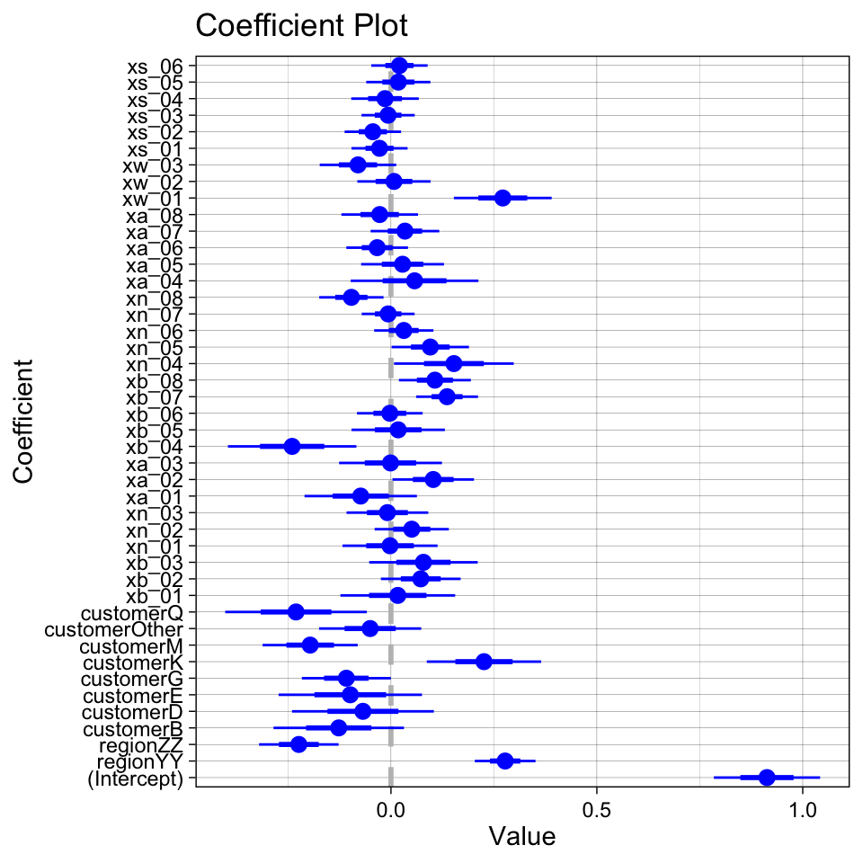

```r
coefplot(mod_2A3)
```

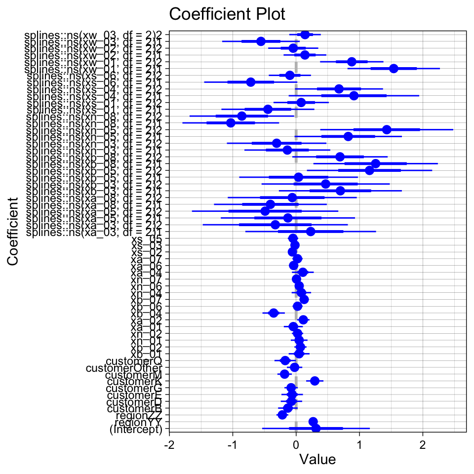

```r
coefplot(mod_2Ac1)
```

[figure not shown]

```r
coefplot(mod_2Ac3)
```

### Important Features

**Extract significant coefficients and arrange by overall score.**

```r
mod_2A3 %>% pull_lm_coefs_signif() %>% knitr::kable()
```

| coef | score |
| --- | --- |
| regionYY | 7.530465 |
| regionZZ | 4.632886 |
| xw_01 | 4.573344 |
| xb_07 | 3.623804 |
| customerM | 3.398498 |
| customerK | 3.252609 |
| xb_04 | 3.076718 |
| customerQ | 2.681217 |
| xn_08 | 2.462515 |
| xb_08 | 2.441883 |

```r
mod_2Ac1 %>% pull_lm_coefs_signif() %>% knitr::kable()
```

| coef | score |
| --- | --- |
| regionYY | 7.460554 |
| regionZZ | 4.649297 |
| customerK | 4.316485 |
| splines::ns(xw_01, df = 2)1 | 4.222023 |
| xb_04 | 4.019778 |
| splines::ns(xw_01, df = 2)2 | 3.511237 |
| xb_07 | 3.444476 |
| customerM | 3.205472 |
| splines::ns(xn_05, df = 2)2 | 2.724878 |
| splines::ns(xn_08, df = 2)1 | 2.704719 |

```r
mod_2Ac3 %>% pull_lm_coefs_signif() %>% knitr::kable()
```

| coef | score |
| --- | --- |
| customerK | 4.267782 |
| regionYY:splines::ns(xw_01, df = 2)1 | 3.557908 |
| xb_04 | 3.538188 |
| customerM | 3.356597 |
| xb_07 | 3.179975 |
| regionYY:splines::ns(xw_01, df = 2)2 | 3.106378 |
| regionYY:splines::ns(xb_03, df = 2)1 | 3.090428 |
| regionYY:splines::ns(xa_08, df = 2)2 | 2.772681 |
| regionYY:splines::ns(xb_08, df = 2)2 | 2.732696 |
| xa_02 | 2.728861 |

- For continuous inputs, potential important ones are `xw_01`, `xb_04`, `xb_07`, `xa_02`.
- For categorical inputs, `region` appears important, and some levels of `customer` too.
- Once we interact `region` to the nonlinear features, it is notable that interaction from `region` is important.